# PML-FinalProject

Amy Galvin

June 4, 2017

## INTRODUCTION

In this project, we look at data from weight lifting exercises (WLE dataset from http://groupware.les.inf.puc-rio.br/har) to determine whether a bicep curl was performed correctly or not.* Specifically, data was collected from accelerometers, gyroscopes, and magnetometers placed on the belt, forearm, arm, and dumbbell of 6 participants.

*It should be noted that not all of the incorrect movements are necessarily incorrect ways of training the biceps. The biceps brachii muscle is composed of 2 muscles: a long head and a short head (hence the name BI-cep). Performing a bicep curl at different angles or performing “partial” curls are, in fact, practiced exercises to train the different heads of the bicep. That being said, it is still interesting to investigate the differences in the measured data for the different movements and make predictions based on these data.

## DATA CLEANING AND CROSS-VALIDATION

For my analyses and predictions, I first cleaned the data to removed columns that contained only NA values and those that contained near zero variance (NZV). The NZV variables are those that have a unique value across predictors or those that have a constant value across all subjects. In order to avoid them inappropriately skewing the model, they are removed from analyses (though in practice, this should be done with caution, as unneccesarily throwing away data can also inappropriately skew the model).

```r
training <- read.csv("pml-training.csv")
testing <- read.csv("pml-testing.csv")

training1 <- training

training2 <- which(colSums(is.na(training1)) > 10000)
training3 <- training1[,-c(training2)]
training4 <- training3

trainingNZV <- nearZeroVar(training4, saveMetrics=TRUE)
training5 <- training4[,trainingNZV$nzv == FALSE]
names <- colnames(training5)
training5 <- training5[c(-1)]
```

After cleaning the data, cross-validation was performed in the provided training dataset using random sampling. This dataset was split into a sub-training set, composed of 60% of the original training data, and a sub-test set, composed of 40% of the original training data.

```r
set.seed(23)
inTrain <- createDataPartition(training5$classe, p=0.6, list = FALSE)
myTraining <- training5[inTrain,]
myTest <- training5[-inTrain,]
```

## MODELING

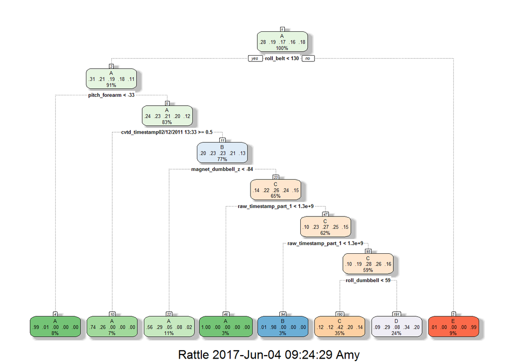

```r
##DECISION TREE
set.seed(23)
modFitTree <- train(classe~., method="rpart", data=myTraining)
predTree <- predict(modFitTree, myTest)
CMTree <- confusionMatrix(myTest$classe, predTree)
fancyRpartPlot(modFitTree$finalModel)
```

```r
##LDA
set.seed(23)
modFitLDA <- train(classe~., method="lda", data=myTraining)
predLDA <- predict(modFitLDA, myTest)
CMLDA <- confusionMatrix(myTest$classe, predLDA)

##RANDOM FORESTS
cluster <- makeCluster(detectCores() - 1)
registerDoParallel(cluster)
fitControl <- trainControl(method = "cv", number = 5, allowParallel = TRUE)

modFitRF <- train(classe~., method="rf",data=myTraining ,trControl = fitControl)

stopCluster(cluster)
registerDoSEQ()

predRF <- predict(modFitRF, myTest)
CMRF <- confusionMatrix(myTest$classe, predRF)
```

```r
Accuracy <- c(CMTree$overall["Accuracy"], CMLDA$overall["Accuracy"], CMRF$overall["Accuracy"])
Method <- c("Decision Tree", "LDA", "Random Forests")

Acc2 <- data.frame(Method, Accuracy)
```

## PREDICTING ON THE FINAL TEST SET

We will clean the test data in the same way that we did the training data. Therefore, we will take the names of the columns (excluding “classe”) from the training data after we have removed the NA and NZV values and extract only those columns from the test data.

```r
names <- colnames(training5)
testnames <- names[1:57]
finalTest <- testing[testnames]
```

Now we will use our Random Forests prediction model to predict the movement type.

```r
predict(modFitRF, finalTest)
```

```
##  [1] B A B A A E D B A A B C B A E E A B B B
## Levels: A B C D E
```

For the sake of comparison, I ran the LDA and Density Tree models on the final test set as well.

```r
predict(modFitLDA, finalTest)
```

```
##  [1] B B B A A E D C A A B C B A E E A B B B
## Levels: A B C D E
```

```r
predict(modFitTree, finalTest)
```

```
##  [1] C C C A A D C D A A D C B A C C C D A B
## Levels: A B C D E
```

## CONCLUSION

In the future, it would be interesting to explore other avenues of this data that were not investigated in this project. For example, the data features time-stamp variables, indicating that there was some time component of the performed exercises. Since I could not find a description of the variables indicating the organization or unit of time used in the dataset, I did not explore this further. Furthermore, since only 6 participants took part in the study, it might be interesting to break-down the dataset by person and run the models per person to see if we got different results for each person. Finally, it would also be interesting to investigate the difference in accelerometer, gyroscope, and magnetometer measurements to see if one of the devices provides more valuable data than the others.